# Introduction to R: Session 1

Eleonora Minaeva, eleonora.minaeva@eui.eu

2023-10-02

## What is R?

R is a statistical computing and graphics system. This system is comprised of two parts: the R language itself and a run-time environment.

**Open Source:** R is an open-source language, which means it’s freely available for anyone to use, modify, and distribute.

**Customization:** R simplifies data manipulation tasks and allows for extensive customization of plots and analyses, giving users the flexibility to tailor their work to specific research needs.

**Integration:** R can be easily integrated with other programming languages like Python, SQL, and C++.

**Reproducibility:** R encourages reproducible research through tools like RMarkdown, making it easy to create dynamic documents that combine code, results, and explanations.

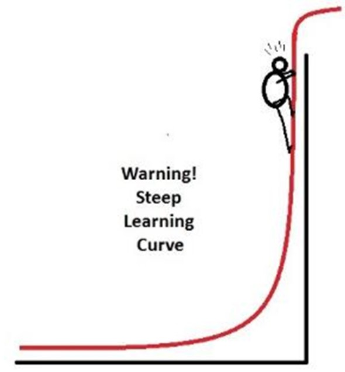

## R sources

- R and RStudio Installers: https://posit.co/download/rstudio-desktop/
- Online planform dedicated to programming and technology-related questions and answers: https://stackoverflow.com/
- Collaborative project development: https://github.com/
- Do not hesitate to use ChatGPT! It corrects and writes new code if you can explain the task

### Some literature:

- Wickham, Hadley, and Garrett Grolemund. “R for Data Science.” O’Reilly Media, 2017.
- Wickham, Hadley. “Advanced R.” Chapman and Hall/CRC, 2019.
- Matloff, Norman. “The Art of R Programming.” No Starch Press, 2011.

## R and RStudio basics

[figure not shown]

R

Compared to the *pure* program R, RStudio provides you with the script window, plot window, environment and console to make it easier to use. However, it is a prerequisite that you know in advance what you want to calculate or display. In RStudio there is no possibility to “click” through the choices as in e.g., SPSS.

[figure not shown]

What R Studio looks like

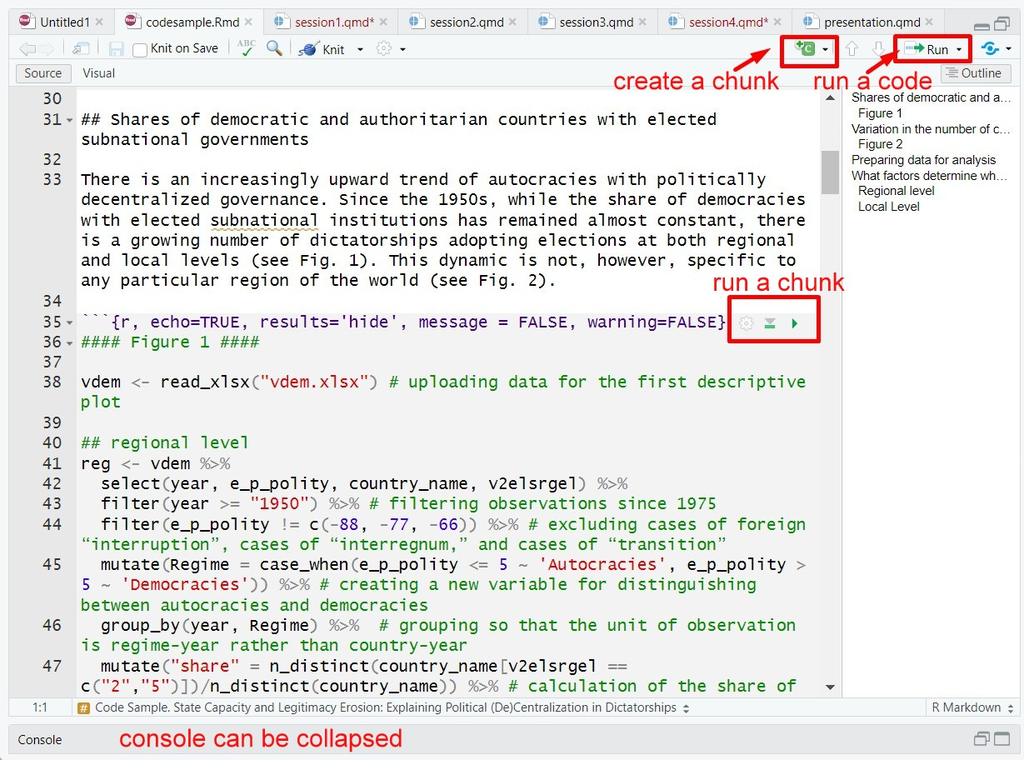

R Markdown

## Check and update your R version

```r
R.version.string
```

1. Install the `installr` Package (if not already installed): **install.packages(“installr”)**
2. **installr::updateR()**
3. Update R packages: **update.packages(ask = FALSE, checkBuilt = TRUE)**

## Installing packages

Installing Packages (usually done once): **`install.packages("package")`**

Loading Packages into the R Workspace (needs to be done each time the program is started): **`library(package)`**

```r
install.packages("data.table")
library(data.table)

# alternatively, you can use 'pacman' package for intalling and uploading several packages at the same time

pacman::p_load(
# the names of all packages you want to install
 tidyverse,
 stargazer,
 lme4,
 ggeffects)


# installed.packages() # check which packages you have installed (in console)

# update.packages() # updating packages

# remove.packages()
```

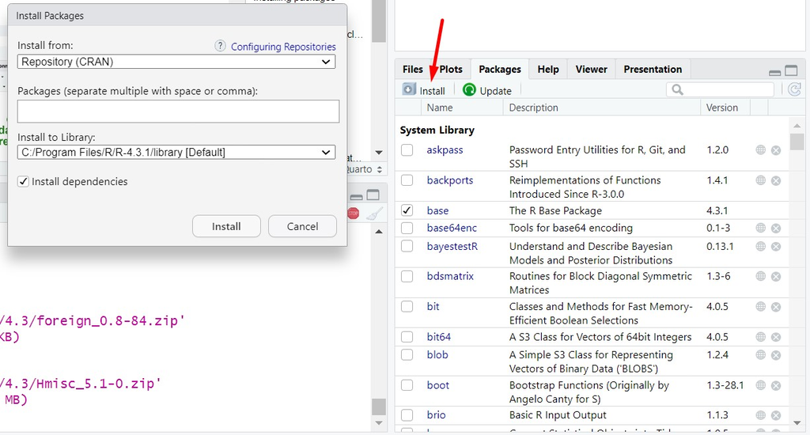

## Syntax

- Running a code

Windows users: **CTRL + Enter**

MacOS users: **Command + Enter (⌘ + Enter)**

- Common logical operators in R include **`==`** (equal), **`!=`** (not equal), **`<`** (less than), **`>`** (greater than), **`<=`** (less than or equal to), **`>=`** (greater than or equal to), **`&`** (and), **`|`** (or), and **`!`** (not).

```r
156+934
```

```
## [1] 1090
```

```r
(5*9231)/10
```

```
## [1] 4615.5
```

```r
6>(-85)
```

```
## [1] TRUE
```

## Assignment operator

```r
x <- 125
print(x)
```

```
## [1] 125
```

In R, the **`<-`** operator is used for assignment. When you use it as shown in your statement, it assigns a value to an object (variable) if that object already exists. If the object doesn’t exist, R will create it and assign the specified value to it. Sometimes, **‘=’** is used instead **‘<-’** but be careful not to confuse this sign with the equals sign **‘==’**.

Keyboard shortcuts for <-

- Windows users: Alt + ’ – ’
- macOS: Option + ’ – ’

## Understanding object classes

### Simple functions

```r
result <- sqrt(x = 16)
result
```

```
## [1] 4
```

**`sqrt()`** - square root function. **`sqrt`** is the name of the function, and within **`()`**, you specify the arguments to which the function with this name will be applied.

**`x`** - denotes the function’s argument (in different functions, arguments can have different names).

**`<-`** - assignment operator

**`result`** - an object in which we store the result of the function’s execution. The names of objects can be different (it’s better to follow a style guide for naming).

*Can you write a function of squaring of 7?*

```r
result2 <- 7^2
```

### Variables

- numerical (discrete, continuous)
- categorical (nominal, ordinal)
- logical (or boolean)

```r
my_numeric <- 42.5

my_character <- "some text"

my_logical <- TRUE
```

Variable types can be changed

```r
my_numeric <- as.character(my_numeric)
class(my_numeric)
```

```
## [1] "character"
```

```r
# see also: as.numeric, as.factor, as.logical, as.Date
```

### Vectors

- ordered sequence of values of the same data type. It can contain numeric values, characters, logical values (TRUE/FALSE), or other data types, as long as all elements in the vector are of the same type:

```r
numeric_vector <- c(1, 10, 49)
character_vector <- c("a", "b", "c")

# changing vector
names(numeric_vector) <- c("Marcelo", "Angela", "Widodo")
numeric_vector
```

```
## Marcelo  Angela  Widodo
##       1      10      49
```

- mathematical operations with vectors

```r
# Summing up votes for political parties
party_votes_2020 <- c(59500, 30100, 18780, 12900)
total_votes_2020 <- sum(party_votes_2020)
total_votes_2020
```

```
## [1] 121280
```

```r
# Distributing seats to each party proportional to their share of the total vote
seats_available <- 17
seat_distribution <- party_votes_2020 / sum(party_votes_2020) * seats_available
seat_distribution
```

```
## [1] 8.340204 4.219162 2.632421 1.808212
```

- create another vector for parties results in 2015, then create a vector **‘vote_change’** based on the difference in values for different years

```r
party_votes_2015 <- c(46070, 29000, 17035, 18000)
vote_change <- party_votes_2020 - party_votes_2015
vote_change
```

```
## [1] 13430  1100  1745 -5100
```

### Matrices

- a set of elements of the same data type (numeric, character/categorical, or boolean) arranged in a fixed number of rows and columns:

```r
m <- matrix(1:9, byrow = TRUE, nrow = 3)
m
```

```
##      [,1] [,2] [,3]
## [1,]    1    2    3
## [2,]    4    5    6
## [3,]    7    8    9
```

```r
# The byrow argument specifies that the matrix is filled with values row by row. If we want the values in the matrix to be filled by columns, we simply place byrow = FALSE

# Rows and columns can be named: rownames(my_matrix) <- row_names_vector; colnames(my_matrix) <- col_names_vector

rownames(m) <- c("Party A", "Party B", "Party C")
m
```

```
##         [,1] [,2] [,3]
## Party A    1    2    3
## Party B    4    5    6
## Party C    7    8    9
```

```r
colnames(m) <- c("2010", "2015", "2020")
m
```

```
##         2010 2015 2020
## Party A    1    2    3
## Party B    4    5    6
## Party C    7    8    9
```

```r
# Summation
rowSums(m)
```

```
## Party A Party B Party C
##       6      15      24
```

```r
colSums(m)
```

```
## 2010 2015 2020
##   12   15   18
```

*Reproduce this text matrix:*

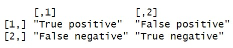

```r
matrix_text <- matrix(c("True positive", "False positive", "False negative", "True negative"), nrow = 2, byrow = TRUE)
```

### Lists

- while matrices hold only one data type (numeric, character, etc.), lists can hold elements of different data types, including vectors, matrices, data frames, other lists, and even functions;
- lists have a flexible structure, and each element can have its own name or be accessed by indexing:

```r
election_results <- list(
  PartyVotes = party_votes_2020,
  SeatDistribution = seat_distribution,
  DeputiesAge = matrix(c(56, 61, 59, 49), nrow = 2)
)
election_results
```

```
## $PartyVotes
## [1] 59500 30100 18780 12900
##
## $SeatDistribution
## [1] 8.340204 4.219162 2.632421 1.808212
##
## $DeputiesAge
##      [,1] [,2]
## [1,]   56   59
## [2,]   61   49
```

### Data frames

- two-dimensional data structure that can combine any types of variables at the same time;
- each column in a data frame represents a variable, and each row represents an observation:

```r
protest_data <- data.frame(
  Date = as.Date(c("2023-08-10", "2023-08-15", "2023-08-20", "2023-08-12")),
  City = c("Berlin", "Strasbourg", "Bologna", "Madrid"),
  Event = c("Protest for Equality", "Environmental Rally", "Labor Strike", "Anti-Corruption Protest"),
  Temperature_Celsius = c(26, 30, 39, 32),
  Participants = c(250, 85, 320, 140)
)
```

- Can you write a missing value in one of the variables? mydata$variable[raw’s number] <- NA

```r
protest_data$Participants[2] <- NA
```

#### Data frames with data.table

```r
protest_data <- data.table(
  Date = as.Date(c("2023-08-10", "2023-08-15", "2023-08-20", "2023-08-12")),
  City = c("Berlin", "Strasbourg", "Bologna", "Madrid"),
  Event = c("Protest for Equality", "Environmental Rally", "Labor Strike", "Anti-Corruption Protest"),
  Temperature_Celsius = c(26, 30, 39, 32),
  Participants = c(250, 85, 320, 140)
)
```

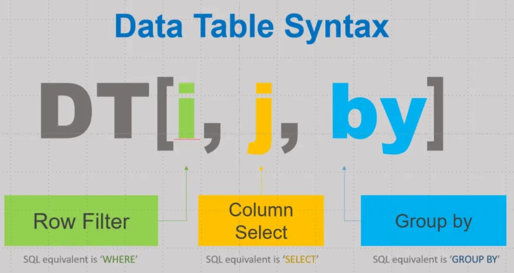

#### Subsetting Rows and Columns

You can easily subset rows and columns using data.table syntax:

- Subset rows based on conditions:

```r
protest_data[City == "Berlin"]
```

```
##          Date   City                Event Temperature_Celsius Participants
## 1: 2023-08-10 Berlin Protest for Equality                  26          250
```

```r
# Can you write a new object 'subset_raws'?
```

- Subset specific columns:

```r
protest_data[, .(Date, City, Event)]
```

```
##          Date       City                   Event
## 1: 2023-08-10     Berlin    Protest for Equality
## 2: 2023-08-15 Strasbourg     Environmental Rally
## 3: 2023-08-20    Bologna            Labor Strike
## 4: 2023-08-12     Madrid Anti-Corruption Protest
```

#### Sorting Data

Sort data by one or more columns:

```r
protest_data[order(Date)]
```

```
##          Date       City                   Event Temperature_Celsius
## 1: 2023-08-10     Berlin    Protest for Equality                  26
## 2: 2023-08-12     Madrid Anti-Corruption Protest                  32
## 3: 2023-08-15 Strasbourg     Environmental Rally                  30
## 4: 2023-08-20    Bologna            Labor Strike                  39
##    Participants
## 1:          250
## 2:          140
## 3:           85
## 4:          320
```

#### Aggregating Data

Perform aggregations on data:

- Calculate mean temperature:

```r
protest_data[, .(Mean_Temperature = mean(Temperature_Celsius))]
```

```
##    Mean_Temperature
## 1:            31.75
```

```r
# Create a new object 'mean_temp'
```

- Group by City and calculate mean participants:

```r
protest_data[, .(Mean_Participants = mean(Participants)), by = City]
```

```
##          City Mean_Participants
## 1:     Berlin               250
## 2: Strasbourg                85
## 3:    Bologna               320
## 4:     Madrid               140
```

#### Data Table Operations

- Add a new column:

```r
protest_data[, Arrested := "0"]
```

- Remove a column:

```r
protest_data[, Arrested := NULL]
```

- Can you add a raw? TIP: function **rbind**

```r
new_row <- data.table(
  Date = as.Date("2023-08-25"),
  City = "Paris",
  Event = "Human Rights March",
  Temperature_Celsius = 28,
  Participants = 200
)

protest_data <- rbind(protest_data, new_row)
```

- Can you remove it?

```r
protest_data <- protest_data[-5, ]
```

## Data overview and summary statistics

```r
dim(protest_data) # number of rows and columns
```

```
## [1] 4 5
```

```r
head(protest_data) # first six rows
```

```
##          Date       City                   Event Temperature_Celsius
## 1: 2023-08-10     Berlin    Protest for Equality                  26
## 2: 2023-08-15 Strasbourg     Environmental Rally                  30
## 3: 2023-08-20    Bologna            Labor Strike                  39
## 4: 2023-08-12     Madrid Anti-Corruption Protest                  32
##    Participants
## 1:          250
## 2:           85
## 3:          320
## 4:          140
```

```r
head(protest_data) # first six rows
```

```
##          Date       City                   Event Temperature_Celsius
## 1: 2023-08-10     Berlin    Protest for Equality                  26
## 2: 2023-08-15 Strasbourg     Environmental Rally                  30
## 3: 2023-08-20    Bologna            Labor Strike                  39
## 4: 2023-08-12     Madrid Anti-Corruption Protest                  32
##    Participants
## 1:          250
## 2:           85
## 3:          320
## 4:          140
```

```r
protest_data[, 'Event'] # accessing a variable
```

```
##                      Event
## 1:    Protest for Equality
## 2:     Environmental Rally
## 3:            Labor Strike
## 4: Anti-Corruption Protest
```

```r
str(protest_data) # summary statistics
```

```
## Classes 'data.table' and 'data.frame':   4 obs. of  5 variables:
##  $ Date               : Date, format: "2023-08-10" "2023-08-15" ...
##  $ City               : chr  "Berlin" "Strasbourg" "Bologna" "Madrid"
##  $ Event              : chr  "Protest for Equality" "Environmental Rally" "Labor Strike" "Anti-Corruption Protest"
##  $ Temperature_Celsius: num  26 30 39 32
##  $ Participants       : num  250 85 320 140
##  - attr(*, ".internal.selfref")=<externalptr>
```

```r
summary(protest_data) # summary statistics
```

```
##       Date                City              Event           Temperature_Celsius
##  Min.   :2023-08-10   Length:4           Length:4           Min.   :26.00
##  1st Qu.:2023-08-11   Class :character   Class :character   1st Qu.:29.00
##  Median :2023-08-13   Mode  :character   Mode  :character   Median :31.00
##  Mean   :2023-08-14                                         Mean   :31.75
##  3rd Qu.:2023-08-16                                         3rd Qu.:33.75
##  Max.   :2023-08-20                                         Max.   :39.00
##   Participants
##  Min.   : 85.0
##  1st Qu.:126.2
##  Median :195.0
##  Mean   :198.8
##  3rd Qu.:267.5
##  Max.   :320.0
```

```r
mean_temp <- mean(protest_data$Temperature_Celsius, na.rm = TRUE) # getting mean by one variable
mean_temp
```

```
## [1] 31.75
```

```r
std_dev_temp <- sd(protest_data$Temperature_Celsius, na.rm = TRUE) # getting standard deviation
std_dev_temp
```

```
## [1] 5.439056
```

## Reproducible workflow

it is an approach in data science where every step of a project is documented and organized in such a way that others (or your **future yourself**) can reproduce the results exactly.

[figure not shown]

### Setting up working directory

- check current location of your directory

```r
getwd()
```

```
## [1] "C:/Program Files/GitHub/IntroR/Session1"
```

- you can change the working directory using the **setwd()** command (set working directory):

```r
setwd()
```

More: https://statisticsglobe.com/function-create-directory-file-path-r

### R Project

If you are working on a single project, such as a prospectus, you can create a separate folder and a dedicated project directory that contains your R scripts, data, and other project-related files. In this case, you do not need to set a new directory, by default it will refer to the folder where you created the project.

Use ‘File’ –> ‘New Project’

More details: https://support.posit.co/hc/en-us/articles/200526207-Using-RStudio-Projects

## Loading data

*You can download data here: https://eui1-my.sharepoint.com/:f:/g/personal/eleonora_minaeva_eui_eu/EgRPuF1LffRPvoWvJ0Z3r5EBjPmlTwFdzlnRhYgO4dMb0A?e=ns1dYO*

*Or here:* https://www.v-dem.net/data/the-v-dem-dataset/country-year-v-dem-fullothers/

### Relative and Absolute Paths

```r
# absolute path
vdem <- read.csv2(file = "C:/Program Files/RStudio/directory/thesis/merging/Vdem/V-Dem-CY-Full+Others-v12.csv", header = TRUE, sep = ",")

# relative path
vdem <- read.csv2(file = "V-Dem-CY-Full+Others-v12.csv", header = TRUE, sep = ",")

# file choose
vdem <- read.csv2(file = file.choose(), header = TRUE, sep = ",")
```

More about organization your directory and uploading files: https://www.r4epi.com/file-paths

## Some typical errors

[figure not shown]

## Some typical errors

#### **Unmatched parentheses, curly braces, square brackets or quotes**

```r
mean(c(1, 7, 13)
```

```r
sex_vector <- c("Male","Female","Female",Male")
factor_sex_vector == as.factor(sex_vector)
```

```r
install.packages(MASS)
```

#### **Wrong, inappropriate or inconsistent data types**

```r
gender <- factor(c("female", "female", "male", "female", "male"))
mean(gender)
```

```r
y <- c(2.4, 3.7, 5.1, "9.8")
class(y)
```

#### **Missing, incorrect or misspelled arguments in functions**

```r
rnorm(n = 3, var = 1) # use ?help for getting information about this function
```

```r
mean(c(1, 7, 13, NA), narm = TRUE)
```

More: https://statsandr.com/blog/top-10-errors-in-r/